# Disaster Relief Project

Jie Tang

Mar 29, 2022

**SYS 6018 | Spring 2022 | University of Virginia**

# 1 Introduction

Our project is aiming to predict the classification of imagery data in Haiti after the earthquake happened in 2010. Because of this huge earthquake, people who living in Haiti were displaced. Now we have ability to obtain those imagery data by a team from the Rochester Institute of Technology flew an aircraft to collect high resolution geo-referenced imagery. To find the right place from those images more effectively, we wish to design models for us to help us do this thing and that is our motivation.

# 2 Training Data / EDA

Load data, explore data, etc.

```r
# Load Required Packages
library(tidyverse)
library(ggplot2)
library(glmnet)
library(broom)
library(FNN)
library(e1071)
library(yardstick)
library(caret)
#Load our csv data file
data = read.csv('HaitiTraining.csv')

#Check the columns of Haiti data
head(data)
```

```
#>        Class Red Green Blue
#> 1 Vegetation  64    67   50
#> 2 Vegetation  64    67   50
#> 3 Vegetation  64    66   49
#> 4 Vegetation  75    82   53
#> 5 Vegetation  74    82   54
#> 6 Vegetation  72    76   52
```

```r
#Check the summary of our data
#summary(data$Class)
#Hmisc::describe(data$Class)
Hmisc::describe(data)
```

```
#> data
#>
#>  4  Variables      63241  Observations
#> --------------------------------------------------------------------------------
#> Class
#>        n  missing distinct
#>    63241        0        5
#>
#> lowest : Blue Tarp        Rooftop          Soil             Various Non-Tarp Vegetation
#> highest: Blue Tarp        Rooftop          Soil             Various Non-Tarp Vegetation
#>
#> Value             Blue Tarp          Rooftop             Soil Various Non-Tarp
#> Frequency              2022             9903            20566             4744
#> Proportion            0.032            0.157            0.325            0.075
#>
#> Value            Vegetation
#> Frequency             26006
#> Proportion            0.411
#> --------------------------------------------------------------------------------
#> Red
#>        n  missing distinct     Info     Mean      Gmd      .05      .10
#>    63241        0      208    0.977      163    87.78       63       68
#>      .25      .50      .75      .90      .95
#>       80      163      255      255      255
#>
#> lowest :  48  49  50  51  52, highest: 251 252 253 254 255
#> --------------------------------------------------------------------------------
#> Green
#>        n  missing distinct     Info     Mean      Gmd      .05      .10
#>    63241        0      208    0.999    153.7    82.15       63       67
#>      .25      .50      .75      .90      .95
#>       78      148      226      252      255
#>
#> lowest :  48  49  50  51  52, highest: 251 252 253 254 255
#> --------------------------------------------------------------------------------
#> Blue
#>        n  missing distinct     Info     Mean      Gmd      .05      .10
#>    63241        0      212        1    125.1    69.23       50       52
#>      .25      .50      .75      .90      .95
#>       63      123      181      200      213
#>
#> lowest :  44  45  46  47  48, highest: 251 252 253 254 255
#> --------------------------------------------------------------------------------
```

We have 63241 data and no missing one. So we do not need to fill in or replace anything. Meanwhile, except the “Class” variable, all other predictors are numeric which means we do not need to use encoding to category variable. There are in total five classes of ‘class’ which are Blue Tarp, Rooftop, Soil, Various Non-Trap and Vegetation. Vegetation has the most proportion and Blue Tarp has the least.

And the range for color should be inside 0 to 255.

Some preprocessing: Change the multi-class prediction to binary prediction. Most of our models only fit with binary classifcation. And in our case, I consider the Blu Tarp is the most significant place to clarify. Becuase people who displaced will live with a tarp and they will need resources.

```r
#The class variable is categorical so I want to encode it to numeric, 1 stand for Blue Tarp and 0 stand for non-Blue Tarp image.
head(data$Class)
```

```
#> [1] "Vegetation" "Vegetation" "Vegetation" "Vegetation" "Vegetation"
#> [6] "Vegetation"
```

```r
data$Class <- ifelse(data$Class == "Blue Tarp", 1, 0)
head(data$Class)
```

```
#> [1] 0 0 0 0 0 0
```

TRAING TEST SPLIT

```r
#This chunk is for splitting the trainning and testing data
set.seed(1)

#80% training and 20% testing
train_size <- floor(0.8 * nrow(data))

train_ind <- sample(seq_len(nrow(data)), size = train_size)

train <- data[train_ind, ]
test <- data[-train_ind, ]


predictor = c("Red", "Green", "Blue")
train.X = subset(train, select=predictor)
train.Y = train["Class"]
test.X = subset(test, select=predictor)
test.Y = test["Class"]
#Make those matrix to fit  and predict model
train.X <- as.matrix(train.X)
train.Y <- as.matrix(train.Y)
test.X <- as.matrix(test.X)
test.Y <- as.matrix(test.Y)
```

So, we have 50592 training data and 12649 testing data.

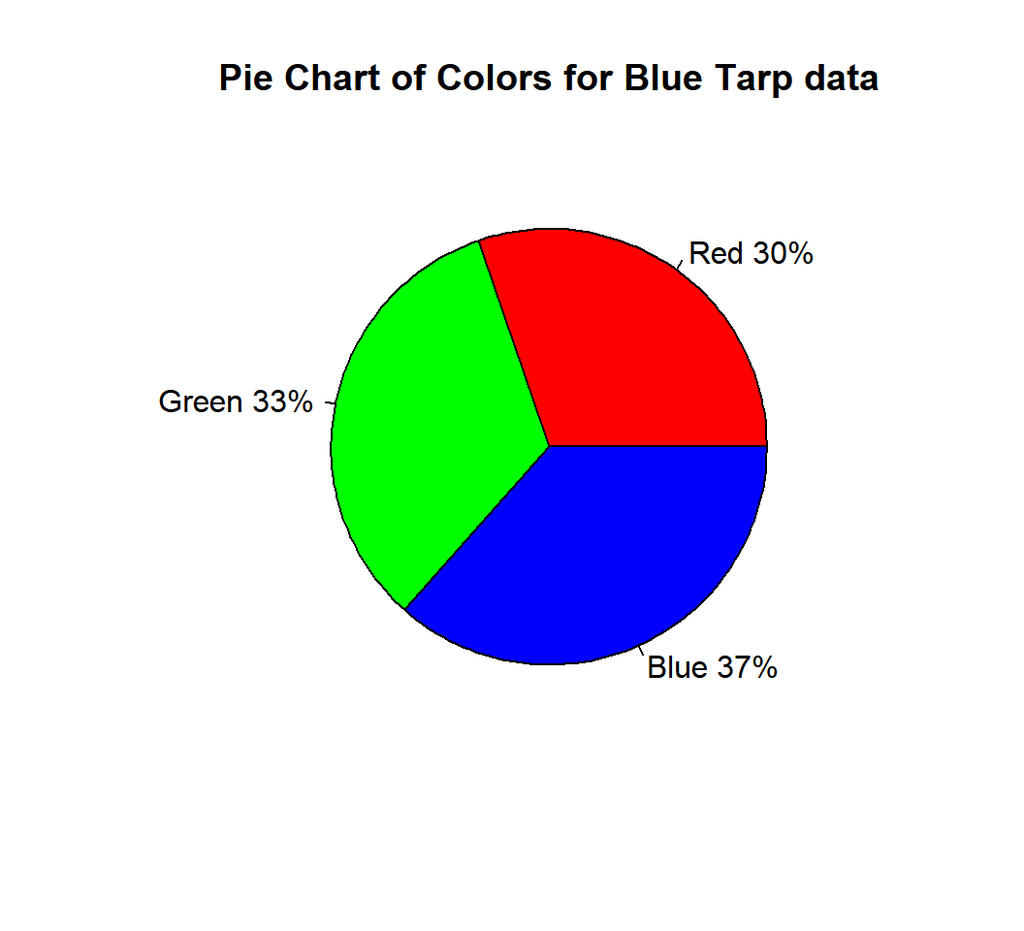

```r
#Let's take Blue Tarp class as an example, I suppose the blue numeric number will have the most porpotion.
tarp_data = subset(data, data$Class==1)
slices <- c(sum(tarp_data$Red), sum(tarp_data$Green), sum(tarp_data$Blue))
lbls <- c("Red", "Green", "Blue")
cols <- c("Red", "Green", "Blue")
pct <- round(slices/sum(slices)*100)
lbls <- paste(lbls, pct)
lbls <- paste(lbls,"%",sep="")
pie(slices, labels = lbls, main="Pie Chart of Colors for Blue Tarp data", col=cols)
```

Blue is the most. But does not over too many. We can not simply predict it by which color is the most.

# 3 Model Training

For all these four models, I will use all of the predictors because 3 is quite small and we only have those variables.

## 3.1 Set-up

```r
#- Get K-fold partition (so consistent to all models)
set.seed(1) # set seed for replicability
n.folds = 10 # number of folds for cross-validation
fold = sample(rep(1:n.folds, length=nrow(train.X)))
```

## 3.2 Logistic Regression

Logistics regression. I will use all three data to do the model fitting. Using traincontrol() to do cross validation

```r
# define training control
train_control <- trainControl(method = "cv", number = 10,)

# train the model on training set
model <- train(Class ~ Blue+Green+Red,
               data = train,
               trControl = train_control,
               method = "glm",
               family=binomial())
# print cv scores
summary(model)
```

```
#>
#> Call:
#> NULL
#>
#> Deviance Residuals:
#>     Min       1Q   Median       3Q      Max
#> -3.4080  -0.0203  -0.0014   0.0000   3.8302
#>
#> Coefficients:
#>             Estimate Std. Error z value Pr(>|z|)
#> (Intercept)  0.22442    0.21000   1.069    0.285
#> Blue         0.47006    0.01748  26.889   <2e-16 ***
#> Green       -0.19936    0.01502 -13.269   <2e-16 ***
#> Red         -0.27716    0.01528 -18.142   <2e-16 ***
#> ---
#> Signif. codes:  0 '***' 0.001 '**' 0.01 '*' 0.05 '.' 0.1 ' ' 1
#>
#> (Dispersion parameter for binomial family taken to be 1)
#>
#>     Null deviance: 14351.2  on 50591  degrees of freedom
#> Residual deviance:  1382.6  on 50588  degrees of freedom
#> AIC: 1390.6
#>
#> Number of Fisher Scoring iterations: 12
```

```r
log_prediction = predict(model, test)
# Changing probabilities, threshold is 0.5
log_prediction <- ifelse(log_prediction > 0.5, 1, 0)
log_table = table(test$Class, log_prediction)
log_table
```

```
#>    log_prediction
#>         0     1
#>   0 12237    12
#>   1    54   346
```

```r
log_acc = 1 - ((54+12)/12649)
log_acc
```

```
#> [1] 0.9947822
```

## 3.3 KNN

```r
#Tuning parameter k that we gonna test
K = c(15, 12, 10, 8, 7, 6, 5, 4, 3)

# Using a loop to do knn fitting
data_knn = tibble()
for(k in K){
  knn = knn.reg(train.X,
                y = train.Y,
                test=train.X,
                k=k)
  knn.test = knn.reg(train.X,
                y = train.Y,
                test=test.X,
                k=k)
  #These commented codes are the attempt of using acc to be the evaluation. But the model (or fitting function) I already used is regression. So, I use mse to compare result.
  #misClassError.train <- mean(knn$pred != train.Y)
  #misClassError.test <- mean(knn$pred != test.Y)
  #acc.train = 1 - misClassError.train
  #acc.test = 1 - misClassError.test
  r = train.Y-knn$pred        # residuals on training data
  mse.train = mean(r^2)
  r.test = test.Y-knn.test$pred # residuals on test data
  mse.test = mean(r.test^2)          # test MSE
  edf = nrow(train.X)/k
  #t = tibble(k=k, edf=edf, acc.train=acc.train, acc.test=acc.test)
  t = tibble(k=k, edf=edf, mse.train=mse.train, mse.test=mse.test)
  data_knn = bind_rows(data_knn, t)

}
```

### 3.3.1 Tuning Parameter $k$

```r
data_knn
```

```
#> # A tibble: 9 x 4
#>       k    edf mse.train mse.test
#>   <dbl>  <dbl>     <dbl>    <dbl>
#> 1    15  3373.   0.00181  0.00271
#> 2    12  4216    0.00173  0.00267
#> 3    10  5059.   0.00170  0.00267
#> 4     8  6324    0.00163  0.00266
#> 5     7  7227.   0.00161  0.00264
#> 6     6  8432    0.00159  0.00256
#> 7     5 10118.   0.00147  0.00254
#> 8     4 12648    0.00139  0.00254
#> 9     3 16864    0.00129  0.00264
```

```r
knn.best= knn(train,
               test,
                cl=train$Class,
                k=5)
knn.best2= knn.reg(train.X,
               train.Y,
                test = test.X,
                k=5)

knn_cm <- table(test$Class, knn.best)
knn_cm
```

```
#>    knn.best
#>         0     1
#>   0 12232    17
#>   1    13   387
```

```r
knn_acc = 1 - ((17+13)/12649)
knn_acc
```

```
#> [1] 0.9976283
```

From the result table above, we can obtain a best parameter which is 5. And I also try the knn classifier with k = 5. We have a really high accuracy which is 0.9976.

## 3.4 Penalized Logistic Regression (ElasticNet)

```r
#I want to use elastic net to do Penalized Regression. And throught cv.glmnet, we can do the cross validation.
data_elastic = tibble()
for(i in 0:10){
  fit.enet = cv.glmnet(train.X, train.Y, alpha=i/10, foldid=fold)
  beta.enet = coef(fit.enet, s="lambda.min")
  yhat.enet = predict(fit.enet, newx = test.X, s="lambda.min")
  mse = mean(test.Y - yhat.enet)^2
  #Set Threshold to 0.5
  yhat.enet <- ifelse(yhat.enet > 0.5, 1, 0)
  acc = 1 - mean(test.Y != yhat.enet)
  t = tibble(alpha=i/10, lambdamin=fit.enet$lambda.min, mse=mse, acc=acc)
  data_elastic = bind_rows(data_elastic, t)
}
```

### 3.4.1 Tuning Parameters

At the above fitting part, I used for loop to loop the alpha parameter. Based on the alpha number, I chose lambda.min as the lambda number.

```r
data_elastic
```

```
#> # A tibble: 11 x 4
#>    alpha lambdamin          mse   acc
#>    <dbl>     <dbl>        <dbl> <dbl>
#>  1   0   0.00422   0.0000000139 0.969
#>  2   0.1 0.0000672 0.0000000585 0.980
#>  3   0.2 0.0000707 0.0000000585 0.980
#>  4   0.3 0.0000684 0.0000000586 0.980
#>  5   0.4 0.0000678 0.0000000587 0.980
#>  6   0.5 0.0000717 0.0000000587 0.980
#>  7   0.6 0.0000790 0.0000000587 0.980
#>  8   0.7 0.0000816 0.0000000587 0.980
#>  9   0.8 0.0000783 0.0000000588 0.980
#> 10   0.9 0.0000839 0.0000000589 0.980
#> 11   1   0.0000909 0.0000000589 0.980
```

```r
best_eln = cv.glmnet(train.X, train.Y, alpha = 1, fold=fold)
pred = predict(best_eln, test.X, s="lambda.min")
pred <- ifelse(pred > 0.5, 1, 0)
eln_cm = table(test$Class, pred)
eln_cm
```

```
#>    pred
#>         0     1
#>   0 12249     0
#>   1   256   144
```

## 3.5 Support Vector Machines (SVM)

I am gonna use all three variables and polynomial kernel function to fit SVM model.

```r
data_svm = tibble()
for(degree in 2:4){
  acc = 0
  for(f in 1:n.folds){
    fit = svm(factor(Class) ~ Blue + Green + Red,
      data = train[fold != f, ],
      #: tuning parameters
      kernel = "poly",
      degree = degree,
      cost = 1
    )
    pred = predict(fit, train[fold == f,], decision.values = TRUE)

    eval_data = tibble(
      outcome = train$Class[fold == f],
      pred_hard = c(pred),
      pred_soft = as.numeric(attr(pred, "decision.values")))
    missing_classerr <- mean(eval_data$outcome != eval_data$pred_hard)
    acc = acc + 1 - missing_classerr
  }
  t = tibble(degree=degree, acc=acc/10)
  data_svm = bind_rows(data_svm, t)
}
```

### 3.5.1 Tuning Parameters

```r
data_svm
```

```
#> # A tibble: 3 x 2
#>   degree   acc
#>    <int> <dbl>
#> 1      2 0.993
#> 2      3 0.991
#> 3      4 0.990
```

```r
best_svm = svm(factor(Class) ~ Blue + Green + Red,
      data = train,
      #: tuning parameters
      kernel = "poly",
      degree = 2,
      cost = 1)

pred = predict(fit, test, decision.values = TRUE)
eval_data = tibble(
    outcome = test.Y,
    pred_hard = c(pred),
    pred_soft = as.numeric(attr(pred, "decision.values")))

svm_cm <- table(test$Class, eval_data$pred_hard)
```

We can see that when the degree is 2. The performance is the best.

**NOTE: PART II same as above plus add Naive Bayes, LDA, QDA, Random Forest, and Boosted Trees to Model Training.**

## 3.6 Threshold Selection

For logistic regression and penalized logistic regression, both of them return a value but not 0 or 1. So I selected threshold to 0.5 to select the classifcation of result.

# 4 Results (Cross-Validation)

```r
#Logistic regrssion
log_acc
```

```
#> [1] 0.9947822
```

```r
log_table
```

```
#>    log_prediction
#>         0     1
#>   0 12237    12
#>   1    54   346
```

```r
log_tpr = 12237/(12237+12)
log_fpr = 54/(54+346)
log_pre = 12237/(12237+54)
#knn
data_knn
```

```
#> # A tibble: 9 x 4
#>       k    edf mse.train mse.test
#>   <dbl>  <dbl>     <dbl>    <dbl>
#> 1    15  3373.   0.00181  0.00271
#> 2    12  4216    0.00173  0.00267
#> 3    10  5059.   0.00170  0.00267
#> 4     8  6324    0.00163  0.00266
#> 5     7  7227.   0.00161  0.00264
#> 6     6  8432    0.00159  0.00256
#> 7     5 10118.   0.00147  0.00254
#> 8     4 12648    0.00139  0.00254
#> 9     3 16864    0.00129  0.00264
```

```r
knn_cm
```

```
#>    knn.best
#>         0     1
#>   0 12232    17
#>   1    13   387
```

```r
knn_acc
```

```
#> [1] 0.9976283
```

```r
knn_tpr = 12232/(12232+17)
knn_fpr = 13/(13+387)
knn_pre = 12232/(12232+13)
#penalized logistic regression
eln_cm
```

```
#>    pred
#>         0     1
#>   0 12249     0
#>   1   256   144
```

```r
eln_tpr = 12249/(12249+0)
eln_fpr = 256/(144+256)
eln_pre = 12249/(12249+256)
#svm
data_svm
```

```
#> # A tibble: 3 x 2
#>   degree   acc
#>    <int> <dbl>
#> 1      2 0.993
#> 2      3 0.991
#> 3      4 0.990
```

```r
svm_cm
```

```
#>
#>         0     1
#>   0 12249     0
#>   1   130   270
```

```r
svm_tpr = 12249/(12249+0)
svm_fpr = 128/(272+128)
svm_pre = 12249/(12249+128)
```

## 4.1 Performance Table

```r
library(knitr)
performance_table = tibble(Model=c("Log Reg", "KNN", "Penalized Log Reg", "SVM"), Tuning=c("None", "k=5", "alpha=1","degree=2"), AUROC="AUROC", Threshold=c("0.5","None","0.5","None"), Accuracy=c("99.48%","99.76%","97.97%", "99.34%"), TPR=c(log_tpr,knn_tpr,eln_tpr,svm_tpr), FPR=c(log_fpr, knn_fpr,eln_fpr,svm_fpr), Precision=c(log_pre, knn_pre, eln_pre, svm_pre))
knitr::kable(performance_table, "pipe")
```

[output not shown]

## 4.2 ROC Curves

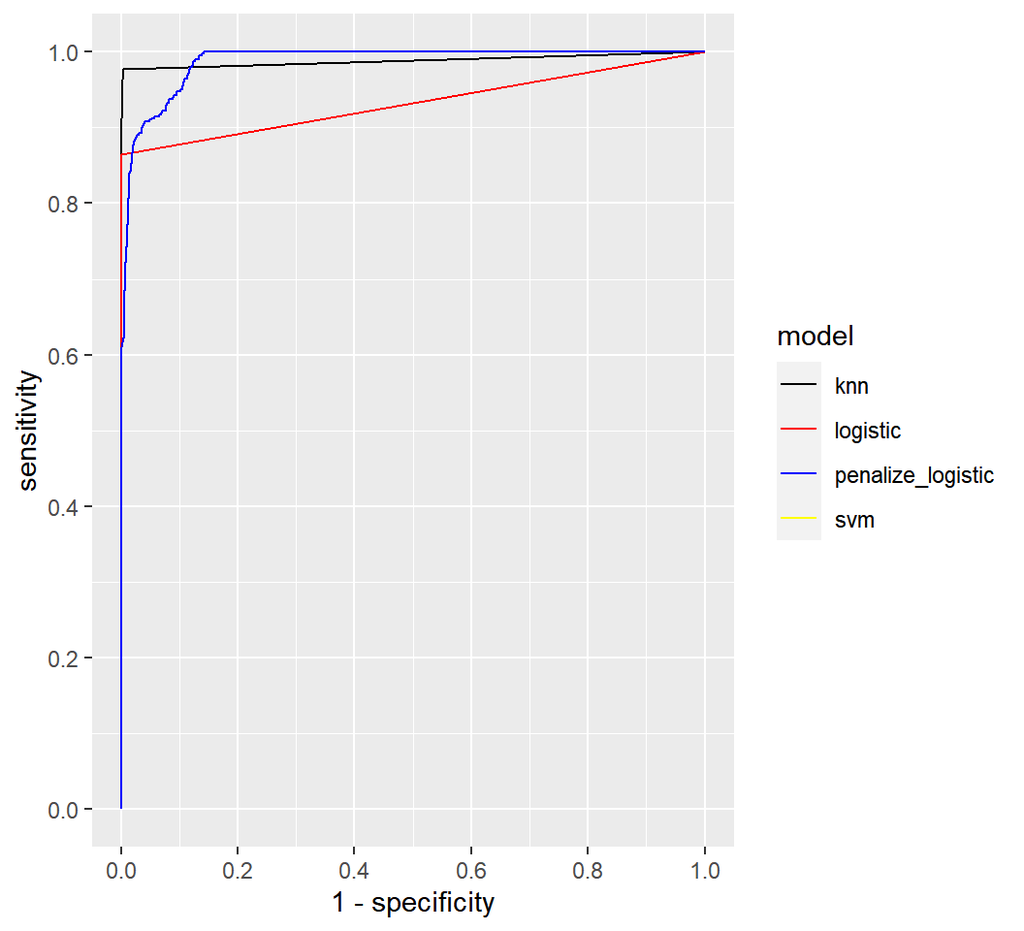

```r
pred_data =
  tibble(
    logistic = log_prediction,
    knn = knn.best2$pred,
    penalize_logistic = predict(best_eln, s="lambda.min", newx=test.X)[,1],
    svm = eval_data$pred_soft,
    linked = test.Y %>% factor(levels=c(1,0))
  ) %>%  # note: response must be a factor
  # convert to long format
  gather(model, prediction,logistic, knn, penalize_logistic) %>%
  # get performance for each model
  group_by(model) %>%
  roc_curve(truth = linked, prediction)          # get ROC curve data
#: plot ROC curve
pred_data %>%
  ggplot(aes(1-specificity, sensitivity, color=model)) +
  geom_path() +
  scale_color_manual(values=c(knn='black', logistic='red', penalize_logistic='blue', svm='yellow')) +
  scale_x_continuous(breaks=seq(0, 1, by=.2)) +
  scale_y_continuous(breaks=seq(0, 1, by=.2))
```

# 5 Conclusions

### 5.0.1 Conclusion #1

In conclusion, based on the test result we created from above, we can see the knn model have an overall outstanding performance compared to other model result. Based on the accuracy, FPR and precision, knn is my best choice of model in this project. However, all models have a pretty high accuracy and gap between those models actually small. But knn has its own advantage. It is easy to implement, fast to fit the model and easy to explain.

### 5.0.2 Conclusion #2

I think one improvement should be the tuning part of svm. Because I used 10-fold cross validation and it is really time consuming to tuning the parameter of svm. Same thing in other hyper parameter tuning, I have space to try a bigger range of value. Also threshold is another aspect that I can improve. From our ROC cruve, we can see that the highest point for logistic and penalize logistic is not exactly 0.5. So my results from logistic and penalize logistic have space to improve.

### 5.0.3 Conclusion #3

From results shown above, seems like a higher edf(or we could say higher variance) may not lead a better performance. The normal reason for this is obviously the overfitting in our training data. Because of the bias-variance trade off, we wish to find a balance point between them. That’s why I split the test data and used it during the model fitting. There is another point I think is our variables are good enough for us to predict whether it is a image of blue tarp or not. We can see that our test results are all nearly perfect. We do not need to somehow extend extra feature space or limit the coefficent of original variables. So, we can see that the peanlize logistic regression even perform worse than logistic regression. Thus, to fit a better or effective model, have a nice understanding to your dataset is significantly important.